# Vision industrielle - TP 2

L'objectif de ce TP est de découvrir et d'utiliser des outils d'apprentissages automatiques (machine-learning) dans le cadre de la vision par ordinateur. Le langage de programmation Python sera utilisé, ainsi que les librairies scientifiques suivantes:

- NumPy
- SciPy
- matplotlib
- scikit-image
- sklearn

## Objectif : reconnaitre des chiffres et des lettres de façon automatique

### Les données

Dans un premier temps nous chargeons une base d'image de chiffres manuscrits.

```
Nombre d'image = 1797
Quelques exemples de chiffres présents dans cette base
```

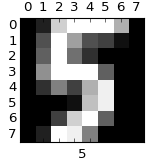

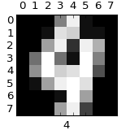

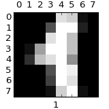

```python
import matplotlib.pyplot as plt
import sklearn
from sklearn import datasets
digits = sklearn.datasets.load_digits()
print("Nombre d'image = {}".format(digits.data.shape[0]))
print("Quelques exemples de chiffres présents dans cette base")

display_image_nb(digits.images[32], title=digits.target[32])
display_image_nb(digits.images[14], title=digits.target[14])
display_image_nb(digits.images[11], title=digits.target[11])
```

De combien d'image est constitués le tableau. Quelle est la taille de chaque image ?

```python
print("Il s'agit d'un tableau de {} images, de taille {}x{}".format(*digits.images.shape))
```

```
Il s'agit d'un tableau de 1797 images, de taille 8x8
```

Pour chaque image, nous disposons d'un label correspondant au chiffre présent dans l'image. Ce label est diponnible dans le *tableau digits.target*.

```python
digits.target[11]  # le label associé à l'image 11
```

```
1
```

Quelle chiffre est présent dans l'image 389 ?

```python
digits.target[389]
```

```
3
```

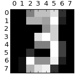

```python
display_image_nb(digits.images[389])
```

Remarquons enfin que les images sont aussi disponnibles en format "plat" (flatten), dans le tableau digits.data

```python
digits.images[3].flatten()
```

```
array([  0.,   0.,   7.,  15.,  13.,   1.,   0.,   0.,   0.,   8.,  13.,
         6.,  15.,   4.,   0.,   0.,   0.,   2.,   1.,  13.,  13.,   0.,
         0.,   0.,   0.,   0.,   2.,  15.,  11.,   1.,   0.,   0.,   0.,
         0.,   0.,   1.,  12.,  12.,   1.,   0.,   0.,   0.,   0.,   0.,
         1.,  10.,   8.,   0.,   0.,   0.,   8.,   4.,   5.,  14.,   9.,
         0.,   0.,   0.,   7.,  13.,  13.,   9.,   0.,   0.])
```

```python
digits.data[3]
```

```
array([  0.,   0.,   7.,  15.,  13.,   1.,   0.,   0.,   0.,   8.,  13.,
         6.,  15.,   4.,   0.,   0.,   0.,   2.,   1.,  13.,  13.,   0.,
         0.,   0.,   0.,   0.,   2.,  15.,  11.,   1.,   0.,   0.,   0.,
         0.,   0.,   1.,  12.,  12.,   1.,   0.,   0.,   0.,   0.,   0.,
         1.,  10.,   8.,   0.,   0.,   0.,   8.,   4.,   5.,  14.,   9.,
         0.,   0.,   0.,   7.,  13.,  13.,   9.,   0.,   0.])
```

```python
digits.data.shape
```

```
(1797, 64)
```

Le module sklearn (http://scikit-learn.org) offre un ensemble de fonctions permetant d'utiliser facilement des méthodes d'apprentissages automatisés.

```python
import sklearn.svm

# création d'un classifieur de type SVM (support vector classifier)
classifier = sklearn.svm.SVC(gamma=0.0001)

# Apprentissage en utilisant la deuxième moitiée de la base de donnée
index = digits.data.shape[0]/2
X = digits.data[index:, :]
Y = digits.target[index:]
classifier.fit(X,Y)

# Maintenant on va utiliser le classifieur pour "prédire"
# les valeurs présentes dans la première partie de la base de donnée
predicted = classifier.predict(digits.data[:index])
expected = digits.target[:index]
```

Quelle est la valeur prédite pour le chiffre à la position 15, quelle est la valeur attendue ? La prédiction est t'elle correcte ? Afficher l'image correspondante

Même question pour l'image à la position 120.

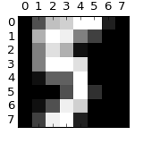

```
Valeur prédite pour le chiffre à la position 15 = 5, valeur attendue 5
```

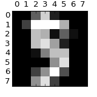

```
Valeur prédite pour le chiffre à la position 120 = 9, valeur attendue 5
```

```python
i = 15
display_image_nb(digits.images[i])
print("Valeur prédite pour le chiffre à la position {} = {}, valeur attendue {}".format(i, predicted[i], expected[i]))

i = 120
display_image_nb(digits.images[i])
print("Valeur prédite pour le chiffre à la position {} = {}, valeur attendue {}".format(i, predicted[i], expected[i]))
```

### Analyse des performances.

```python
from sklearn import metrics
print("Confusion matrix:\n{}".format(metrics.confusion_matrix(expected, predicted)))
```

```
Confusion matrix:
[[90  0  0  0  0  0  0  0  0  0]
 [ 0 90  0  0  0  0  1  0  0  0]
 [ 0  7 80  0  0  0  0  1  3  0]
 [ 0  0  0 84  0  0  0  0  7  1]
 [ 0  5  0  0 83  0  0  1  0  0]
 [ 0  0  0  0  0 86  0  0  2  3]
 [ 0  0  0  0  0  1 88  0  1  0]
 [ 0  0  0  0  1  2  0 85  0  2]
 [ 0  9  0  0  0  0  1  0 76  0]
 [ 0  5  0  0  2  0  0  4  3 74]]
```

En utilisant cette matrice de confusion, répondez au question suivantes:

- Combien de fois le chiffre 9 a été bien prédit ? (**True positive**, **HIT**)

```python
74
```

```
74
```

- Combien de fois le chiffre 9 à été prédit alors qu'il s'agissait d'un autre chiffre ? (**False positive**)

```python
1+3+2
```

```
6
```

- Combien de fois un chiffre autre que 9 a été prédit alors que le chiffre 9 était attendu ? (**False Negative**)

```python
5+2+4+3
```

```
14
```

Quel est le pourcentage de bonnes réponses du classifieur (accuracy)?

```python
accuracy = (90 + 90 + 80 + 84 + 83 + 86 + 88 + 85 + 76 + 74) / len(predicted)
print("accuracy is {}".format(accuracy))


# vous pouvez aussi utiliser
from sklearn import metrics
metrics.accuracy_score(expected, predicted)
```

```
accuracy is 0.9309576837416481
```

```
0.93095768374164811
```

Quel est la précision pour le chiffre 9? Quel est le rappel pour le chiffre 9 ?

```python
precision = 74 / (74+6)
print("precision = {}".format(precision))

recall = 74 / (74 + 14.)
print("recall = {}".format(recall))
```

```
precision = 0.925
recall = 0.8409090909090909
```

Sklearn fournit une méthode de génération de rapport sur un classifieur: metrics.classification_report.

Utilisez cette méthode pour afficher le rapport concernant le classifieur précédent.

```python
from sklearn import metrics
print("Classification report for classifier %s:\n%s\n"
      % (classifier, metrics.classification_report(expected, predicted)))
```

```
Classification report for classifier SVC(C=1.0, cache_size=200, class_weight=None, coef0=0.0, degree=3,
  gamma=0.0001, kernel='rbf', max_iter=-1, probability=False,
  random_state=None, shrinking=True, tol=0.001, verbose=False):
             precision    recall  f1-score   support

          0       1.00      1.00      1.00        90
          1       0.78      0.99      0.87        91
          2       1.00      0.88      0.94        91
          3       1.00      0.91      0.95        92
          4       0.97      0.93      0.95        89
          5       0.97      0.95      0.96        91
          6       0.98      0.98      0.98        90
          7       0.93      0.94      0.94        90
          8       0.83      0.88      0.85        86
          9       0.93      0.84      0.88        88

avg / total       0.94      0.93      0.93       898
```

Cross validation

Apprendre sur des données et tester sur ces mêmes données est une erreur méthodologique. Il faut toujours évaluer les performances sur des données qui n'ont pas été utilisées pour l'apprentissage. Cette approche nécessite d'avoir un jeu de donnée d'apprentissage (X_learn, Y_learn) et un jeu de donnée de test (X_test, Y_test).

Cependant partitionner les données disponnibles en deux ensembles réduit drastiquement le nombre de données utilisables pour apprendre le modèle, de plus le résultat pourrait être dépendant du choix du partitionement.

Une solution est d'utiliser un schéma de type cross-validation.

Lisez la documentation de cross_validation.cross_val_score et utilisez cette méthode.

```python
from sklearn import cross_validation
scores = cross_validation.cross_val_score(classifier, digits.data, digits.target, cv=10)
print(scores)

#help(classifier.score)  # accuracy = fraction of correct
```

```
[ 0.93513514  0.9726776   0.94475138  0.95        0.95530726  0.98882682
  0.98324022  0.98876404  0.89830508  0.93181818]
```

Exercice:

Classifier le dataset digits avec un classifieur de type nearest neighbors et un classifieur de type gaussian naive bayesian. Garder 20 % des données de côté pour évaluer les performances de chaque classifieur.

```python
from sklearn.naive_bayes import GaussianNB
from sklearn.neighbors import KNeighborsClassifier
from sklearn.datasets import load_digits
```

```python
#Une solution:
from sklearn.naive_bayes import GaussianNB
from sklearn.neighbors import KNeighborsClassifier
from sklearn.datasets import load_digits

knn = KNeighborsClassifier(3)
gaussian = GaussianNB()

digits = load_digits()
n = int(digits.target.size * 0.8)
print(n)
X_train = digits.data[0:n]
Y_train = digits.target[0:n]
X_test = digits.data[n:]
Y_test = digits.target[n:]
print(X_train.shape)
print(X_test.shape)

knn.fit(X_train, Y_train)
gaussian.fit(X_train, Y_train)
gaussian_predicted = gaussian.predict(X_test)
knn_predicted = knn.predict(X_test)

score_gaussian = np.sum((gaussian_predicted == Y_test)) / Y_test.size
score_knn = np.sum((knn_predicted == Y_test)) / Y_test.size
print("Score gaussian = {}".format(score_gaussian))
print("Score knn = {}".format(score_knn))
```

```
1437
(1437, 64)
(360, 64)
Score gaussian = 0.7916666666666666
Score knn = 0.9666666666666667
```

# Et si on travaillait avec des images plus grandes..

Mnist dataset: The MNIST database contains a total of 70000 examples of handwritten digits of size 28x28 pixels, labeled from 0 to 9.

http://yann.lecun.com/exdb/mnist/

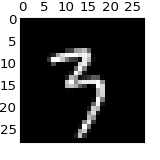

```python
from sklearn.datasets import fetch_mldata
mnist = fetch_mldata('MNIST original', data_home=".")
image_nb = mnist.data[22222].copy()
image_nb.shape = (28,28)
image_nb.shape

display_image_nb(image_nb)
```

Utilisez la méthode cross_validation.cross_val_score pour évaluer un classifieur de type naive_bayes sur ces données.

Quelle solution pouvez vous proposez pour améliorer les résultats ?

```python
from sklearn import linear_model
from sklearn.naive_bayes import GaussianNB

clf = GaussianNB()
scores = cross_validation.cross_val_score(clf, mnist.data, mnist.target, cv=3)
print(scores)
```

```
[ 0.52224032  0.50079287  0.51978055]
```

Utilisez la lib skimage, et notamment feature.hog pour générer des histogram of gradients pour chaque image, utilisez ces features pour entrainer votre classifieur, quelle accuracy obtenez vous ?

```python
from sklearn.naive_bayes import GaussianNB
from sklearn.neighbors import KNeighborsClassifier
from sklearn.datasets import load_digits
from skimage.feature import hog
from sklearn import cross_validation

list_of_features = []
for image in mnist.data:
    image.shape = (28,28)
    descriptor = hog(image, orientations=8, pixels_per_cell=(4, 4), cells_per_block=(1, 1), visualise=False)
    list_of_features.append(descriptor)
clf = GaussianNB()
#clf.fit(mnist.data, mnist.target)
#scores = cross_validation.cross_val_score(clf, mnist.data, mnist.target, cv=3)
#print(scores)
```

```python
scores = cross_validation.cross_val_score(clf, list_of_features, mnist.target, cv=3)
print(scores)
```

```
[ 0.73847275  0.73942485  0.7419742 ]
```

```python
from sklearn import linear_model
clf = linear_model.LogisticRegression()
scores = cross_validation.cross_val_score(clf, list_of_features, mnist.target, cv=3)
print(scores)
```

```
[ 0.96773226  0.96562808  0.97038275]
```